# Predict costs and optimize spending for Azure

#### 8.5 Bring your own SQL Server license

If you are a customer on an Enterprise Agreement and already have an investment in SQL Server licenses, and they have freed up as part of moving resources to Azure, you can provision **bring your own license** (BYOL) images off the Azure Marketplace, giving you the ability to take advantage of these unused licenses and reduce your Azure VM cost. You've always been able to use these licenses by provisioning a Windows VM and manually installing SQL Server, but this process simplifies the creation process by leveraging Microsoft certified images. Search for **BYOL** in the Marketplace to find these images.

[figure not shown]

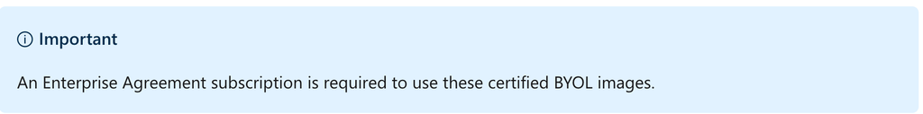

#### 8.6 Use SQL Server Developer Edition

Many people are unaware that SQL Server Developer Edition is a free product for **nonproduction use**. Developer Edition has all the same features that Enterprise Edition has, but for nonproduction workloads, you can save dramatically on your licensing costs.

Look for SQL Server images for Developer Edition on the Azure Marketplace and use them for development or testing purposes to eliminate the additional cost for SQL Server in these cases.

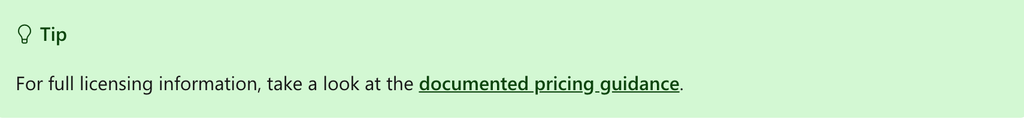

#### 8.7 Use constrained instance sizes for database workloads

Many customers have high requirements for memory, storage, or I/O bandwidth. But they also often have low requirements for CPU core counts. Based on this popular request, Microsoft has made available the most popular VM sizes (DS, ES, GS, and MS) in new sizes that constrain the vCPU count to one half or one-quarter of the original VM size, while maintaining the same memory, storage, and I/O bandwidth.

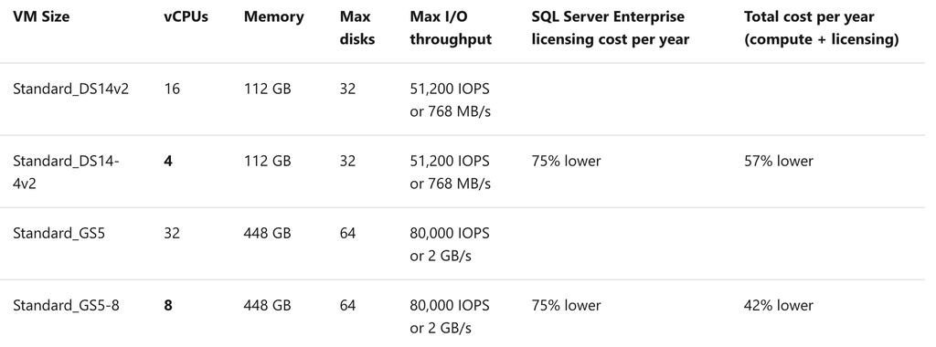

Because database products like SQL Server and Oracle are licensed per CPU, customers can reduce licensing cost by up to 75 percent and still maintain the high performance their database requires.

#### 8.8 Check your knowledge

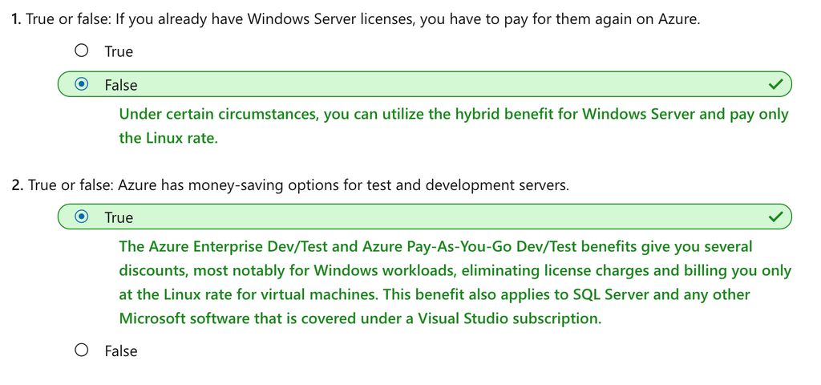

### Topic 9: Summary

We've talked through the Azure pricing calculator and how you can use it to estimate your costs on Azure and compare pricing between different service offerings. We looked at savings options, how to export pricing estimates, and at tools that Azure has available to help you keep your cloud spend in check.

- **Azure Advisor** provides *recommendations* in many areas, including cost.
- **Azure Cost Management** gives you *reporting and billing information*, so you can gain insights into where you're spending your money.

We then explored best practices to help you save money on both infrastructure and licensing.

#### 9.1 Learn more

To learn more about getting more insights into your Azure costs, visit the following articles:

- [Azure Architecture Center](https://docs.microsoft.com/azure/architecture)
- [Cost optimization pillar of the Azure Well-Architected Framework](https://docs.microsoft.com/azure/architecture/framework/cost/overview)
- [Setting up spending limits in Azure](https://docs.microsoft.com/azure/billing/billing-spending-limit)
- [Azure budgets](https://docs.microsoft.com/azure/billing/billing-cost-management-budget-scenario)
- [Explore flexible purchasing options for Azure](https://azure.microsoft.com/pricing/purchase-options/)
- [Understand terms on your Microsoft Azure invoice](https://docs.microsoft.com/azure/billing/billing-understand-your-invoice)
- [Bandwidth Pricing Detailss](https://azure.microsoft.com/pricing/details/bandwidth/)

#### 9.2 Check your knowledge

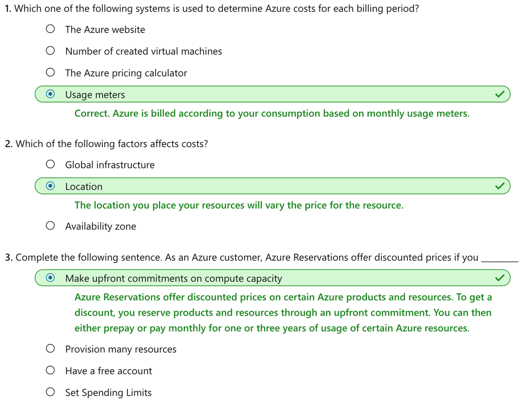